# MFD project and subprojects report

M. Albertsen & F. Delogu

# Setup

This section is meant for internal use and debugging, if you are interest in seeing the code please knit again the document setting the “debug” flag to “true”. Optionally, set “debug2” as “true” to see also the code to generate the debug headings and text.

For the generation of this document the parameters were set as:

| param | value |
| --- | --- |
| debug | FALSE |
| debug2 | FALSE |
| internal | TRUE |

# Project specific curation

## P01_1: Biowide - Original

### Description

P01_1: Biowide (Biodiversity in Width and Depth). In light of the biodiversity crisis and our limited ability to explain variation in biodiversity, tools to quantify spatial and temporal variation in biodiversity and its underlying drivers are critically needed. Inspired by the recently published ecospace framework, we developed and tested a sampling design for environmental and biotic mapping. We selected 130 study sites (40×40 m) across Denmark using stratified random sampling along the major environmental gradients underlying biotic variation. Using standardized methods, we collected site species data on vascular plants, bryophytes, macrofungi, lichens, gastropods and arthropods. To evaluate sampling efficiency, we calculated regional coverage (relative to the known species number per taxonomic group), and site scale coverage (i.e., sample completeness per taxonomic group at each site). To extend taxonomic coverage to organisms that are difficult to sample by classical inventories (e.g., nematodes and non-fruiting fungi), we collected soil for metabarcoding. Finally, to assess site conditions, we mapped abiotic conditions, biotic resources and habitat continuity. The main paper is described here: https://bmcecol.biomedcentral.com/articles/10.1186/s12898-019-0260-x. See a list of related publications here: https://ecos.au.dk/forskningraadgivning/temasider/publikationer.

### Info

**Extended metadata:** Environmental parameters; alternative habitat classifications; plant counts; animal counts; fungal counts; ITS2 amplicons; trnL amplicons.

**People:** Tobias Guldberg Frøslev < tobiasgf@sund.ku.dk>; Rasmus Ejrnæs rasmus@bios.au.dk

**Responsible:** Thomas Bygh Nymann Jensen tbnj@bio.aau.dk`

**Comments:** `

### Data

The samples from the P01_1 project were collected in the following locations:

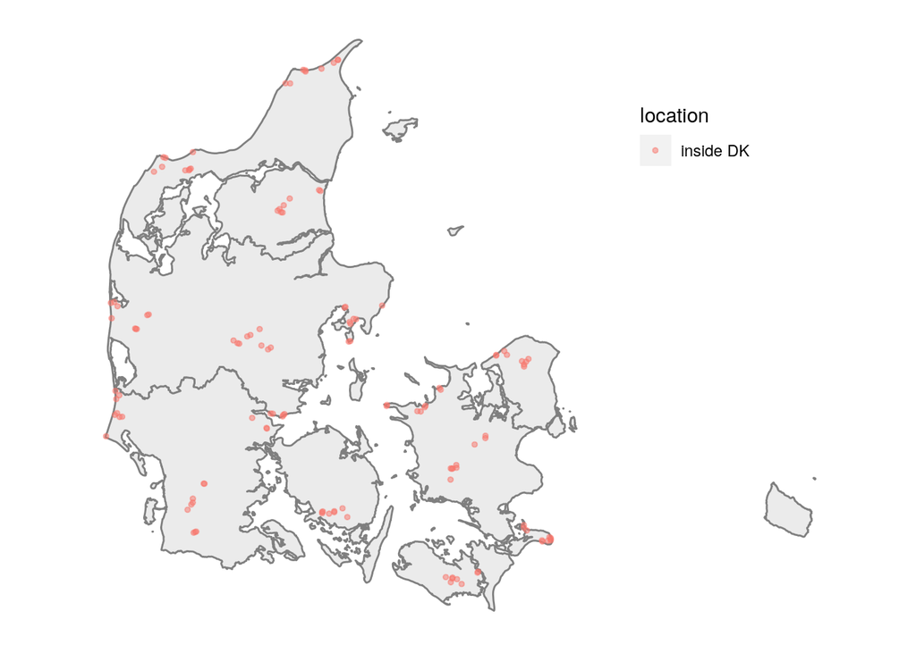

|  | V1 |
| --- | --- |
| project_id | P01_1 |
| n_samples | 130 |
| gps | 130 |
| sampling_date | 0 |
| mfd_areatype | 130 |
| mfd_sampletype | 130 |
| mfd_hab1 | 103 |
| mfd_hab2 | 78 |
| mfd_hab3 | 1 |
| gps_date_hab1 | 0 |

| mfd_areatype | mfd_sampletype | mfd_hab1 | mfd_hab2 | mfd_hab3 | n |
| --- | --- | --- | --- | --- | --- |
| Agriculture | Soil | Fields | NA | NA | 10 |
| Natural | Soil | Bogs, mires and fens | Fen wetland (non-habitat .. | NA | 37 |
| Natural | Soil | Coastal | Salt marshes and salt mea.. | Atlantic salt meadows | 1 |
| Natural | Soil | Forrests | NA | NA | 15 |
| Natural | Soil | Grassland formations | Grasslands (non-habitat t.. | NA | 18 |
| Natural | Soil | Grassland formations | Semi-natural tall-herb hu.. | NA | 8 |
| Natural | Soil | Heath and scrub | Temperate heath | NA | 14 |
| Natural | Soil | NA | NA | NA | 27 |

### Missing data

The following data are missing, for which a mitigation strategy is suggested:

| info | status | mitigation |
| --- | --- | --- |
| project_id | complete | No action needed |
| description | complete | No action needed |
| extended_metadata | complete | No action needed |
| people | complete | No action needed |
| responsible | complete | No action needed |
| comment | incomplete | Ask: Thomas Bygh Nymann Jensen tbnj@bio.aau.dk |

### Metadata summary

| field | present | present [%] | missing | missing [%] |
| --- | --- | --- | --- | --- |
| fieldsample_barcode | 130 | 100.00 | 0 | 0.00 |
| sample_type | 130 | 100.00 | 0 | 0.00 |
| latitude | 130 | 100.00 | 0 | 0.00 |
| longitude | 130 | 100.00 | 0 | 0.00 |
| habitat_type | 130 | 100.00 | 0 | 0.00 |
| habitat_typenumber | 130 | 100.00 | 0 | 0.00 |
| sitename | 130 | 100.00 | 0 | 0.00 |
| received | 125 | 96.15 | 5 | 3.85 |
| sampling_comment | 130 | 100.00 | 0 | 0.00 |
| project_id | 130 | 100.00 | 0 | 0.00 |
| mfd_sampletype | 130 | 100.00 | 0 | 0.00 |
| mfd_areatype | 130 | 100.00 | 0 | 0.00 |
| sampling_date | 0 | 0.00 | 130 | 100.00 |
| mfd_hab1 | 103 | 79.23 | 27 | 20.77 |
| mfd_hab2 | 78 | 60.00 | 52 | 40.00 |
| mfd_hab3 | 1 | 0.77 | 129 | 99.23 |

### Metadata entry out of expectations

No samples have unexpected entries.

### Dubious location

No samples were reported from coordinates outside of Danish land.

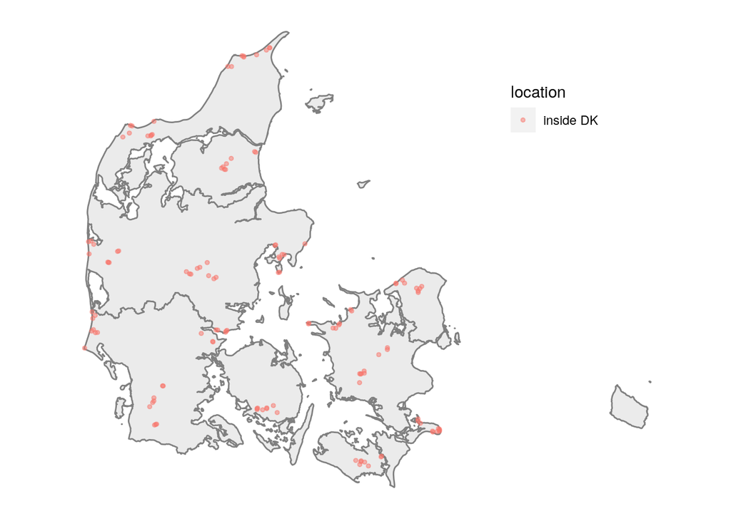